# Bayesian statistics with R: an introduction.

Elizaveta Semenova

date: 13 April 2018

## What we will cover in the next hour

- **What** is Bayesian inference?
- **Why** use Bayesian inference?
- **How** to perform Bayesian inference?

## What we will NOT cover:

- Why should one use Bayesian approach always and **never try anything else.**

## We will use R in the practical part

```r
print("All models are wrong, but some are useful.")
```

```
[1] "All models are wrong, but some are useful."
```

## Pre-requisites

- familiarity with frequentist (classical) statistics,
- installed R/RStudio and Stan.

# WHAT

## What is Bayesian inference?

**Bayesian inference** is the process of deducing properties of a probability distribution from data using Bayes’ theorem.

## Conditional probability

Bayes' theorem relies heavily on the notion of **conditional probability**.

## Conditional probability

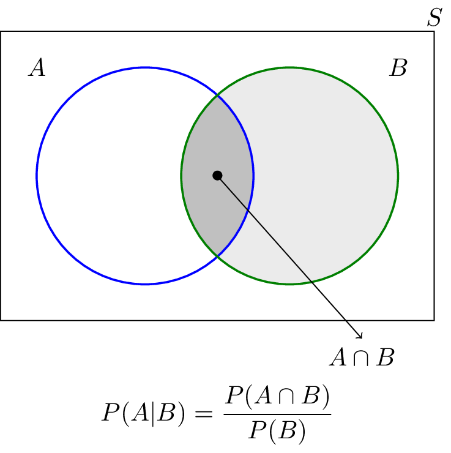

## Conditional probability

Conditional probability of A given B:  
\[ P(A \vert B)=\frac{P(A \cap B)}{P(B)}. \]

\( P(A \vert B) \) - probability of event A given B has occured  
\( P(A \cap B) \) - probability of event A occured and B occured

## Conditional probability: intuition

There are 2 blue and 3 red marbles in the bag.

What is the probability that the first two pulled marbles are blue?

**Solve it intuitively!**

## Bayes' Theorem

From the formula above, we get

\[ P(A \cap B)=P(A \vert B)P(B). \] Similarly, \[ P(A \cap B)=P(B \vert A) P(A). \] Hence, \[ P(A \vert B)P(B)=P(B \vert A) P(A). \]

What can we conclude for \( P(A \vert B) \)?

And we obtain

\[ P(A \vert B)=\frac{P(B \cap A)}{P(B)} = P(B \vert A) \frac{P(A)}{P(B)} \]

The conditional probability of A given B is the conditional probability of B given A scaled by the relative probability of A compared to B.

In practice, we usually want to estimate the unknown model parameters \[ \theta = (\theta_1, ..., \theta_k), \] given the observed data \[ y = (y_1, ..., y_n) \] by using the Bayes' rule: \[ P(\theta \vert y) = \frac{P(y \vert \theta) P(\theta)}{P(y)}. \]

## Bayes' Theorem example: spam filtering

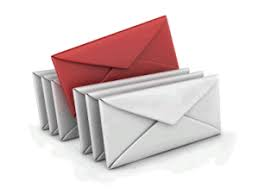

We would like to test a message for being a spam, by checking that it contains a predefined set of words or word combinations, which are common for spam messages (“Free investment”, “Dear email”):  
\[ P(\text{spam } \vert \text{ words}) = \frac{P(\text{spam}) P(\text{words } \vert \text{ spam})}{P(\text{words})} \]

In terms of probability densities  
\[ f(x \vert y)=f(y \vert x) \frac{f(x)}{f(y)} \]  
which is commonly formulated with the proportionality sign:  
\[ f(x \vert y) \propto f(y \vert x) f(x) \]  
since \( f(y) \) does not contain parameters.

The **posterior distribution** is being formed as  
\[ f(\theta \vert y) \propto f(y \vert \theta) f(\theta). \]

- \( f(\theta) \) is the **prioir** and expresses our beliefs about \( \theta \)
- \( f(y \vert \theta) \) is the **likehod** of data \( y \) as a function of \( \theta \)
- we dropped \( f(y) \) because the average likelihood across all parameter values \[ f(y) = \int_{\theta_1} ... \int_{\theta_k} f(\theta) f(y \vert \theta) d\theta_1 ... d\theta_k = E_{\theta}f(y \vert \theta) \] does not depend on \( \theta \) (hence will not influence the inference) and is very hard to compute.

## Components of the bayesian model

- Likelihood
- Prior
- Posterior

\[ \text{Posterior} = \frac{\text{Likelihood × Prior}}{\text{Average Likelihood}} \propto \text{Likelihood × Prior} \]

# WHY

## Diagnosing the cause of headache

[figure not shown]

**Frequentist doctor:**

- Model for the cause of pain (mental)
- Probe with fingers

**Bayesian doctor:**

- Model for the cause of pain (mental)
- History of the patient
- Probe with fingers

**The likelihood principle:** all of the information in a sample is contained in the likelihood function, a density or distribution function.

- The data are modeled by likelihood only.
- Not all statistical paradigms agree with this principle.

## Frequetist vs Bayesian approaches

**Classical (frequentist):**

- parameters are fixed,
- parameters can only be estimated using the current data.

**Bayesian:**

- parameters are described by distributions (i.e. reflecting uncertainty),
- estimation is based on our belief about parameters and the current data.

## Why use Bayesian inference?

- It is a good way to **combine multiple sources of information**,
- It is more **flexible in uncertainty modeling**, particularly under small amount of available data.

Note:

- Results are essentially equal with enough data.

# HOW

## What does it take?

- Data,
- A generative model,
- Our beliefs before seeing the data.

## What does it make?

- The values of parameters that could give rise to the observed data **in the form of a distribution**.

### How

- **analytically**  
  Elegnat, but rarely possible.
- **numerically**
  - Create **posterior** samples, describing the distributions of parameters.
  - We achieve this by exploring the space of parameters to find the most probable combination of parameters.
  - Further we treat the obtained sampled as new data, to extract information about parameters, such as mean and/or credible interval.

### Analytically

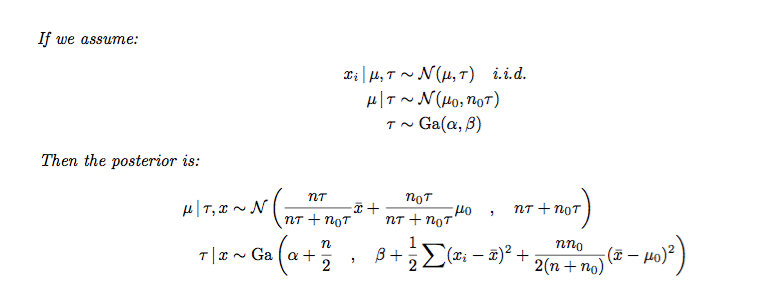

### Numerically

- Markov Chain Monte Carlo
  - Metropolis-Hastings
  - Gibbs
  - Hamiltonian Monte Carlo
- Variational Bayes
- Approximate Bayesian Computation (ABC)
- Particle filters
- Laplace approximation

### Priors

- Informative / Non-informative
- **Conjugate priors** guarantee that the posterior has an easily calculable form.

### Examples

```r
##############################################
# prioir x likelihood = posterior
##############################################

 # define grid
p <- seq( from=0, to=1,length.out=1000)

# compute likelihood at each value in grid
likelihood <- dbinom(6, size=9 , prob=p)
```

### Examples: define a function to compute posterior

```r
computePosterior = function(likelihood, prior){

  posterior <- likelihood*prior
  posterior <- posterior/sum(posterior)

  par(mfrow=c(1,3))
  plot(p, prior, type="l", main="Prioir")
  plot(p, likelihood, type="l", main="Likelihood")
  plot(p, posterior , type="l", main="Posterior")

}
```

### Examples

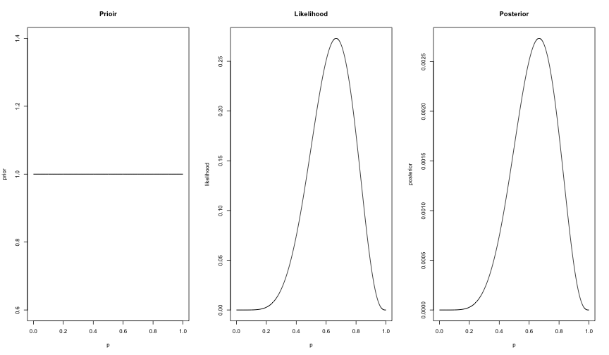

```r
prior1 <- rep( 1 , 1000 )
computePosterior(likelihood, prior1)
```

### Examples

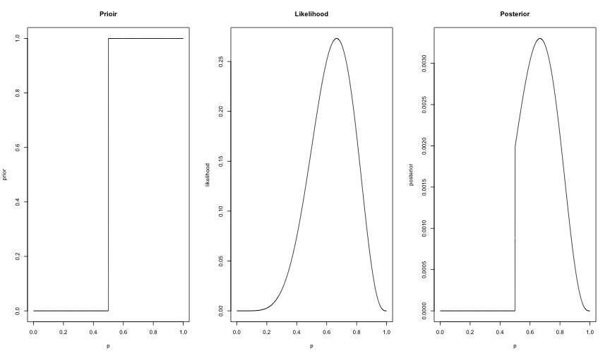

```r
prior2 <- ifelse(p< 0.5 , 0 , 1 )
computePosterior(likelihood, prior2)
```

### Examples

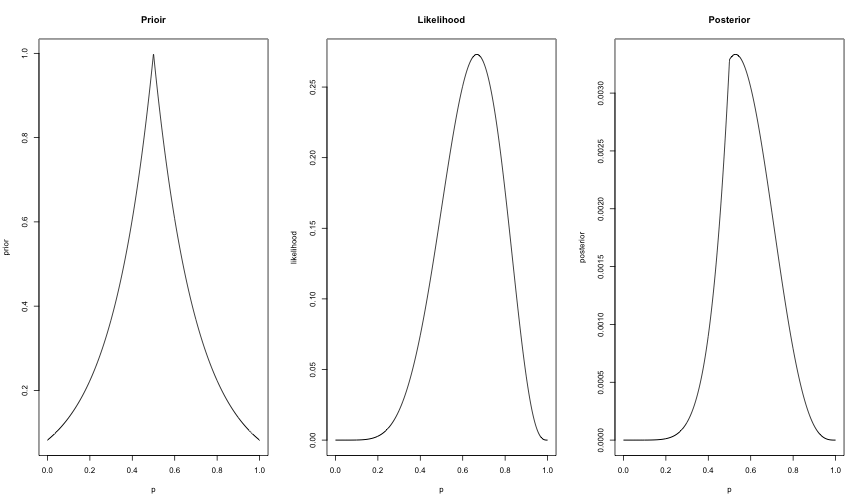

```r
prior3 <- exp( -5*abs( p - 0.5 ))
computePosterior(likelihood, prior3)
```

## Gibbs algorithm

- Start with initial values \( \theta_1^0,...,\theta_n^0. \)
- Sample \( \theta_1^1 ∼ p(\theta_1 \vert \theta_2^0,...,\theta_n^0) \).  
  Current state is \( \theta_1^1,...,\theta_n^0. \)  
  Sample \( \theta_2^1 ∼ p(\theta_2 \vert \theta_1^1,...,\theta_n^0) \).  
  Current state \( \theta_1^1,\theta_2^1,...,\theta_n^0. \)  
  …
- Sample \( \theta_1^2 ∼ p(\theta_2 \vert \theta_2^1,...,\theta_n^1) \).  
  Current state is \( \theta_1^2,...,\theta_n^1. \)  
  and so on.

## Gibbs algorithm

This procedure defines a sequence of random variables

\( (\theta_1^0,...,\theta_n^0), \)  
\( (\theta_1^1,...,\theta_n^1), \)  
…  
\( (\theta_1^N,...,\theta_n^N). \)

We run the chain for \( N \) iterations and discard the first \( B \) samples. This is called **burn-in**.

We can run several parallel versions of the algorithm. Each of them is called a **chain.**

Neigbouring samples will contain similar information. We might want to save only every second, or fifth, or tenth. This is called **thinnning.**

## Gibbs sampler

Let us build the Gibbs sampler fr the following problem:  
\[ \begin{aligned} y_1, ..., y_n &∼ N(\mu, \sigma^2), \\ \mu &∼ N(\mu_0, \sigma^2_0). \end{aligned} \]

Here \( \mu, \sigma^2 \) arethe model *parameters*,  
and \( \mu_0, \sigma^2_0 \) are *hyperparameters*.

## Gibbs sampler

```r
#########################################
# Gibbs sampler: simulate data
#########################################
set.seed(938565)
mu <- 4
sigma2 <- 16
n <- 500
y <- rnorm(n=n, mean=mu, sd=sqrt(sigma2))
```

## Gibbs sampler

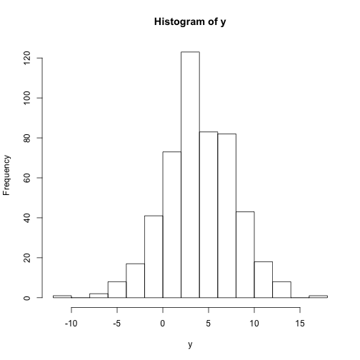

```r
hist(y)
```

## Gibbs sampler

```r
# Define the hyperparameters
mu0 <- -3
sigma2_0 <- 4
a0 <- 1.6
b0 <- 0.4
```

## Gibbs sampler

```r
# parameters for MCMC
niter = 10000
nwarmup = round(niter/2)
nthin = floor((niter-nwarmup)/500)
nchains = 1
parameters = c("mu", "sigma2", "inv_sigma2")
nparameters = length(parameters)
ntot = nwarmup + niter*nthin
```

## Gibbs sampler

```r
# create container to store samples
gibbs_samples <- matrix(NA, nrow=niter, ncol=nparameters)
colnames(gibbs_samples) <- parameters
head(gibbs_samples,3)
```

```
     mu sigma2 inv_sigma2
[1,] NA     NA         NA
[2,] NA     NA         NA
[3,] NA     NA         NA
```

## Gibbs sampler

```r
mu.sim <- rep(NA, length = ntot)
sigma2.sim <- rep(NA, length = ntot)
inv.sigma2.sim <- rep(NA, length = ntot)
```

## Gibbs sampler

```r
#Set the initial value
sigma2.sim[1] <- 1/runif(nchains)

# set the counter
k <- 1
```

## Gibbs sampler

```r
# niter samples after n.burnin taking every n.thin'th sample
dim(gibbs_samples)
```

[output not shown]

```
[1] 10000     3
```

```r
mu_gibbs_samples <- gibbs_samples[,"mu"]
sigma2_gibbs_samples <- gibbs_samples[,"sigma2"]
inv_sigma2_gibbs_samples <- gibbs_samples[,"inv_sigma2"]
```

## Gibbs sampler

For each chain inspect

- Traceplots,
- Histograms,
- Auto-correlation.

## Software

- WinBUGS
- OpenBUGS
- JAGS
- Stan
- R-INLA  
  and more.

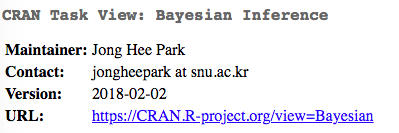

## Stan example

```r
########################################
# Stan example: bernoulli
########################################

# include library
library(rstan)
```

## Stan example

```r
# ground truth value
theta = 0.2

# number of observations to simulate
N = 10000000

y = rbinom(N, prob=theta, size=1)
print(paste0("Proportion of sucesses = ", round(sum(y==1)/sum(y==0),2)))
```

```
[1] "Proportion of sucesses = 0.25"
```

## Stan example

```r
# prepare the data
data_stan = list(N=N, y=y)

# chose your working directory
setwd("~/Dropbox/RLausanne")

# name of the model file
modname = "stan/bernoulli.stan"

# compile
mod = stan_model(modname)
```

[output not shown]

[output cut: 8 more lines]

[output not shown]

## Stan example

```r
# sample
niter = 500
fit = sampling(mod,
               data=data_stan,
               chains = 1,
               warmup=round(niter/2),
               iter=niter,
               thin=5,
               cores = 1,
               refresh = round(niter/100))
```

[output not shown]

[output cut: 56 more lines]

[output not shown]

## Using the draws

We can compute anything on them

## Examples of what one can do with R/Stan

It would be strange if I said nothing about my research. My PhD work includes:

- study of large-scale Gaussian processes to produce smooth maps of spatio-temporal processes,

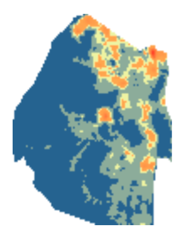

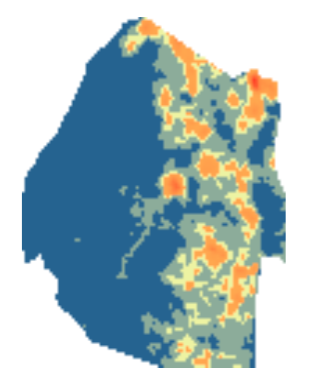

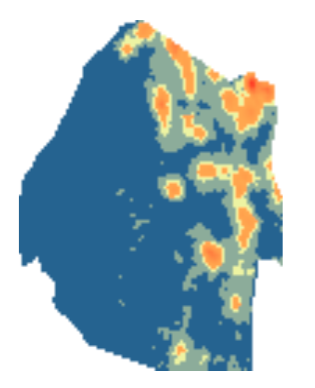

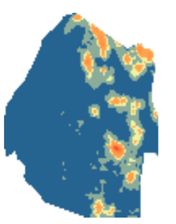

- time series modeling to perform outbreaks detection.

## Literature

- Statistical Rethinking: A Bayesian Course with Examples in R and Stan. By R. McElreath. Chapman and Hall/CRC, 2015.
- Bayesian Data Analysis. By A. Gelman, J.B. Carlin, H.S. Stern, D.B. Dunson, A. Vehtari, D.B. Rubin. Chapman & Hall/CRC, 3rd edition, 2013.
- Doing Bayesian Data Analysis: A Tutorial with R, JAGS and Stan. By J. Kruschke, Academic Press, 2014.

## Conclusion

Trying to learn Bayesian statistics in just one hour is a bit of a joke.

But we managed to understand

- what it is,
- why it is beneficial,
- how to perform Bayesian inference,
- what makes it hard.

Congratulations and thank you!

## Stay in touch

**Twitter**  
@liza_p_semenova  
**Blog**  
elizavetasemenova.github.io  
**E-mail**  
elizaveta.p.semenova @ gmail.com

[figure not shown]